# Shiny: click on a figure to get another

A common task in interactive plotting is to click on figure to extract more information. Shiny is a handy tool for this kind of work. This post demonstrates and explains how to click on a figure to get another using the data from the clicked location.

### Start with an simple example

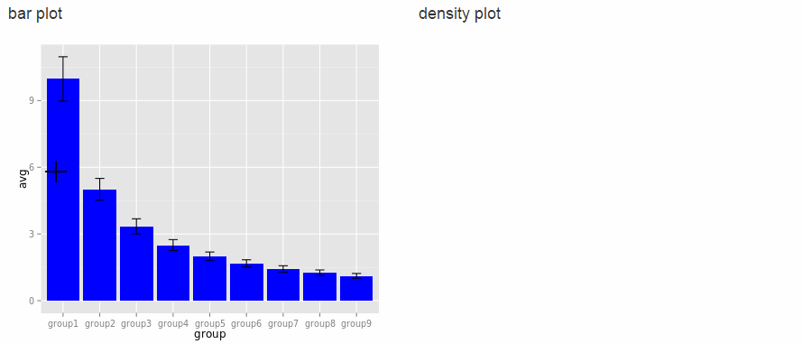

Let’s look at the code. First we need make up some data for the plot. They are just a bunch of dummy data produced for demonstration of the interactive plotting, so you won’t get distracted.

```r
# make up 9 groups of random data
set.seed(1234)
for (i in 1:9) {
    assign(paste0("group", i), (10 + rnorm(1000)) / i)
}

# make a data frame with the 9 groups for easy plotting
df <- data.frame(temp = 1:1000)
for (i in 1:9) {
    df[paste0("group", i)] <- get(paste0("group", i))
}
df$temp <- NULL

# extract mean and standard error for bar plot
avg <- apply(df, 2, mean)
std <- apply(df, 2, sd)
errBar <- data.frame(group = colnames(df), avg = avg, std = std)
```

We now build the shiny app with the data. This app produces the interactive plot above.

```r
library(ggplot2)
ui <- fluidPage(
    fluidRow(
        column(
            width = 6,
            h4("bar plot"),
            plotOutput("bar", click = "clickBar", height = 350)
        ),
        column(
            width = 6,
            h4("density plot"),
            plotOutput("hist", height = 350)
        )
    )
)

server <- function(input, output) {
    # bar plot with error bar
    output$bar <- renderPlot({
        ggplot(errBar, aes(x = group, y = avg)) +
            geom_bar(stat = "identity", fill = "blue") +
            geom_errorbar(aes(ymax = avg + std, ymin = avg - std), width = 0.25)
    })

    # click to generate density plot
    observeEvent(input$clickBar, {
        groupId <- round(input$clickBar$x)
        output$hist <- renderPlot({
            ggplot(df, aes_string(paste0("group", groupId))) +
                geom_density() +
                xlim(c(0, 14)) +
                ylim(c(0, 4)) +
                xlab(paste0("data in group ", groupId) )
        })
    })
}

shinyApp(ui, server)
```

### Understand the parameter `click`

What does the trick is a parameter called `click` of function `plotOutput` in `ui` part of the application. In above example, we name click as `click = "clickBar"`. When you click the figure the `plotOutput` function generates, a signal is sent to the server side of the app, where the signal can be retrieved as `input$clickBar`. Be more specific, `input$clickBar$x` and `input$clickBar$y` are the $(x, y)$ coordinates of the clicked point.

Let’s make a quick example app to show that it is true.

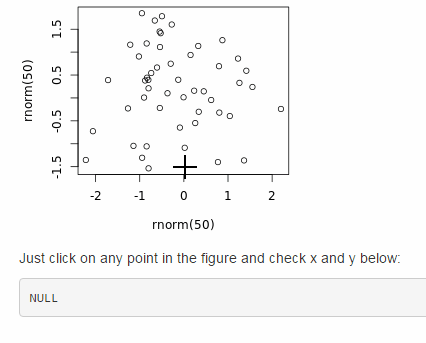

```r
ui <- fluidPage(
    plotOutput("random", click = "clickPoint", width = 300, height = 300),
    p("Just click on any point in the figure and check x and y below:"),
    verbatimTextOutput("clicked")
)

server <- function(input, output) {
    # make up a random plot
    output$random <- renderPlot({
        plot(rnorm(50), rnorm(50))
    })

    # output (x, y) of the clicked point
    output$clicked <- renderPrint({
        c("inupt$clickPoint$x" = input$clickPoint$x, "inupt$clickPoint$y" = input$clickPoint$y)
    })
}

shinyApp(ui,server)
```

Click on the figure and check the output $(x, y)$. Did you see that the $(x, y)$ of clicked point are indeed sent to server side through `inupt$clickPoint$x` and `inupt$clickPoint$y`? Of course, it is true.

We can use the $(x, y)$ of the clicked point to select data. In the bar plot example, we only use the $x$ value to get the groupID. Note that for a categorical variable, the $x$ value is 1 for the first level, 2 for the second, and so on.

```r
groupId <- round(input$clickBar$x)
```

In principle, we can use $(x, y)$ of clicked point as indices to select any possible data at the server side, make whatever you want, and send it back to ui side.